# Final Project-Analysis of housing price in Beijing

```python
for index, row in df.sample(200).iterrows():
    if (row['district'] == 'DongCheng'):
        folium.Marker(location=[row['Latitude'], row['Longitude']], popup="Price per square: " + str(row['price']) + "\n",
                      icon=folium.Icon(color="beige")).add_to(map_osm)
    elif (row['district'] == 'FengTai'):
        folium.Marker(location=[row['Latitude'], row['Longitude']], popup="Price per square: " + str(row['price']) + "\n",
                      icon=folium.Icon(color="black")).add_to(map_osm)
    elif (row['district'] == 'DaXing'):
        folium.Marker(location=[row['Latitude'], row['Longitude']], popup="Price per square: " + str(row['price']) + "\n",
                      icon=folium.Icon(color="orange")).add_to(map_osm)
    elif (row['district'] == 'FaXing'):
        folium.Marker(location=[row['Latitude'], row['Longitude']], popup= "Price per square: " + str(row['price']) + "\n",
                      icon=folium.Icon(color="green")).add_to(map_osm)
    elif (row['district'] == 'FangShang'):
        folium.Marker(location=[row['Latitude'], row['Longitude']], popup="Price per square: " + str(row['price']) + "\n",
                      icon=folium.Icon(color="purple")).add_to(map_osm)
    elif (row['district'] == 'ChangPing'):
        folium.Marker(location=[row['Latitude'], row['Longitude']], popup="Price per square: " + str(row['price']) + "\n",
                      icon=folium.Icon(color="white")).add_to(map_osm)
    elif (row['district'] == 'ChaoYang'):
        folium.Marker(location=[row['Latitude'], row['Longitude']], popup="Price per square: " + str(row['price']) + "\n",
                      icon=folium.Icon(color="red")).add_to(map_osm)
    elif (row['district'] == 'HaiDian'):
        folium.Marker(location=[row['Latitude'], row['Longitude']], popup="Price per square: " + str(row['price']) + "\n",
                      icon=folium.Icon(color="pink")).add_to(map_osm)
    elif (row['district'] == 'ShiJingShan'):
        folium.Marker(location=[row['Latitude'], row['Longitude']], popup="Price per square: " + str(row['price']) + "\n",
                      icon=folium.Icon(color="lightgray")).add_to(map_osm)
    elif (row['district'] == 'XiCheng'):
        folium.Marker(location=[row['Latitude'], row['Longitude']], popup="Price per square: " + str(row['price']) + "\n",
                      icon=folium.Icon(color="drakgray")).add_to(map_osm)
    elif (row['district'] == 'TongZhou'):
        folium.Marker(location=[row['Latitude'], row['Longitude']], popup="Price per square: " + str(row['price']) + "\n",
                      icon=folium.Icon(color="blue")).add_to(map_osm)
    elif (row['district'] == 'ShunYi'):
        folium.Marker(location=[row['Latitude'], row['Longitude']], popup="Price per square: " + str(row['price']) + "\n",
                      icon=folium.Icon(color="cadetblue")).add_to(map_osm)
    elif (row['district'] == 'MenTouGou'):
        folium.Marker(location=[row['Latitude'], row['Longitude']], popup="Price per square: " + str(row['price']) + "\n",
                      icon=folium.Icon(color="lightgreen")).add_to(map_osm)

map_osm
```

Make this Notebook Trusted to load map: File -> Trust Notebook

[interactive chart not shown]

```
No handles with labels found to put in legend.
```

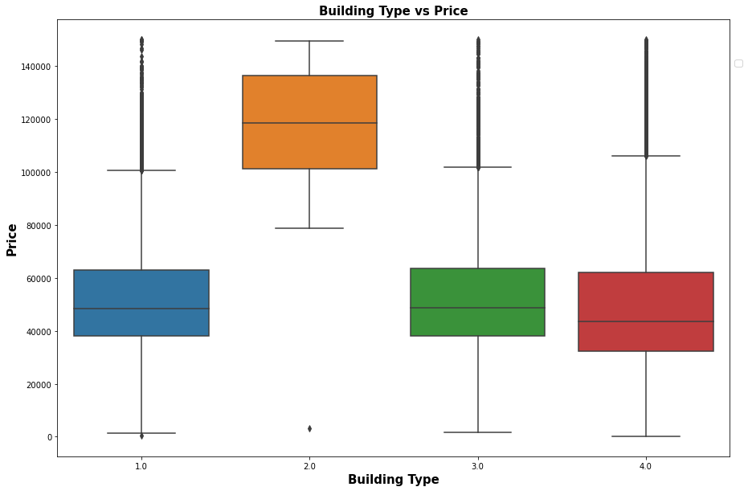

```python
plt.figure(figsize = (15, 10))
sns.boxplot(x = data16['buildingType'], y = data16['price'],data = data16)
#plt.legend(bbox_to_anchor=(1.0, 0.9),loc ='center left', fontsize = 'large')
plt.xlabel("Building Type", size=15, weight='bold')
plt.ylabel("Price",  size=15, weight='bold')
plt.title("Building Type vs Price" , size=15, weight='bold')
```

```
No handles with labels found to put in legend.
```

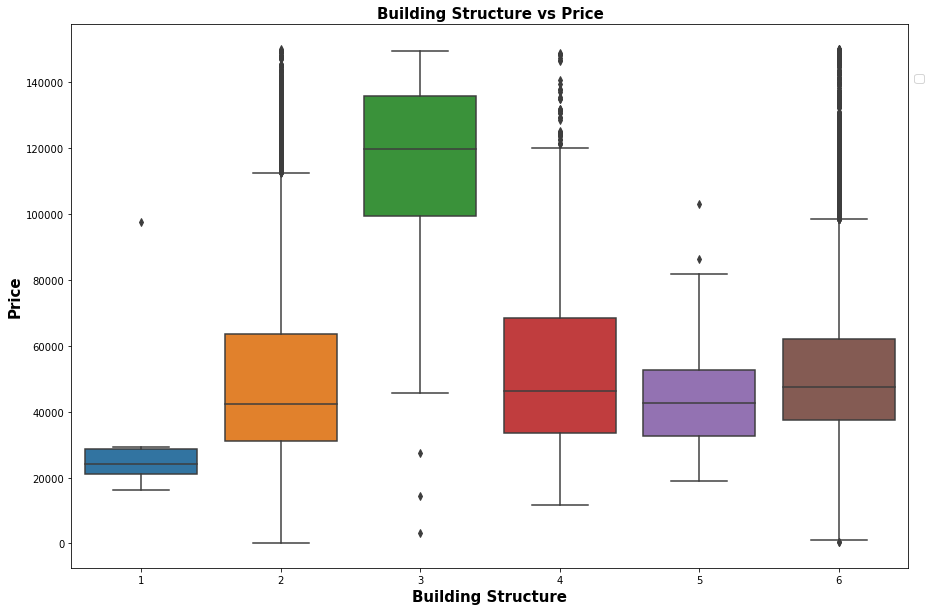

```python
plt.figure(figsize = (15, 10))
sns.boxplot(x = data16['buildingStructure'], y = data16['price'],data = data16)
#plt.legend(bbox_to_anchor=(1.0, 0.9),loc ='center left', fontsize = 'large')
plt.xlabel("Building Structure", size=15, weight='bold')
plt.ylabel("Price",  size=15, weight='bold')
plt.title("Building Structure vs Price" , size=15, weight='bold')
```

From the information we got from the website of this dataset, buildingType: including tower( 1 ) , bungalow( 2 )，combination of plate and tower( 3 ), plate( 4 ) and for the buildingStructure: including unknow( 1 ), mixed( 2 ), brick and wood( 3 ), brick and concrete( 4 ),steel( 5 ) and steel-concrete composite ( 6 ). Looks like Bungalow is the most expensive building type while there is no significant price difference between the remaining three. For the building structure, brick and wood is the most exxpensive one and except the unknow ones, the median price of rest of 4 type are pretty close.